# Is there an association between college major category and income

Tolu Omotunde

24/Sep/2020

## Load a new dataframe called college in R environment

```r
#install.packages("devtools")
devtools::install_github("jhudsl/collegeIncome")
library(reshape)
library(ggplot2)
library(collegeIncome)
data(college)
```

## Next download and install the matahari R package, this package allows a record of your analysis (your R command history) to be documented

```r
devtools::install_github("jhudsl/matahari")
library(matahari)
```

## Begin the documentation of analysis

```r
dance_start(value = FALSE, contents = FALSE)
```

```r
head(college)
```

```
##   rank major_code                                     major major_category
## 1    1       2419                     Petroleum Engineering    Engineering
## 2    2       2416            Mining And Mineral Engineering    Engineering
## 3    3       2415                 Metallurgical Engineering    Engineering
## 4    4       2417 Naval Architecture And Marine Engineering    Engineering
## 5    5       2405                      Chemical Engineering    Engineering
## 6    6       2418                       Nuclear Engineering    Engineering
##   total sample_size perc_women p25th median  p75th   perc_men perc_employed
## 1  2339          36  0.9109326 25000  40000  50000 0.08906743     0.9115044
## 2   756           7  0.5154064 26000  37000  40000 0.48459355     0.7980501
## 3   856           3  0.5942076 26700  45000  60000 0.40579235     0.7871943
## 4  1258          16  0.6521298 26000  35000  45000 0.34787018     0.8465608
## 5 32260         289  0.4179248 31500  62000 109000 0.58207520     0.8515625
## 6  2573          17  0.4305368 23000  44700  50000 0.56946324     0.8474507
##   perc_employed_fulltime perc_employed_parttime
```

[output cut: 20 more lines]

```r
tail(college)
```

```
##     rank major_code                    major            major_category total
## 168  168       3302 Composition And Rhetoric Humanities & Liberal Arts 18953
## 169  169       3609                  Zoology    Biology & Life Science  8409
## 170  170       5201   Educational Psychology  Psychology & Social Work  2854
## 171  171       5202      Clinical Psychology  Psychology & Social Work  2838
## 172  172       5203    Counseling Psychology  Psychology & Social Work  4626
## 173  173       3501          Library Science                 Education  1098
##     sample_size perc_women p25th median  p75th  perc_men perc_employed
## 168         151  0.8459344 30000  42000  65000 0.1540656     0.7636511
## 169          47  0.7643203 50000  65000 102000 0.2356797     0.6757741
## 170           7  0.8644561 33000  46000  58000 0.1355439     0.7932137
## 171          13  0.8128766 22000  29000  38000 0.1871234     0.8017061
## 172          21  0.5847764 39000  48000  58000 0.4152236     0.7403101
## 173           2  0.3212961 22500  38400  45000 0.6787039     0.8194622
##     perc_employed_fulltime perc_employed_parttime
```

[output cut: 20 more lines]

```r
str(college)
```

```
## 'data.frame':    173 obs. of  19 variables:
##  $ rank                            : int  1 2 3 4 5 6 7 8 9 10 ...
##  $ major_code                      : int  2419 2416 2415 2417 2405 2418 6202 5001 2414 2408 ...
##  $ major                           : chr  "Petroleum Engineering" "Mining And Mineral Engineering" "Metallurgical Engineering" "Naval Architecture And Marine Engineering" ...
##  $ major_category                  : chr  "Engineering" "Engineering" "Engineering" "Engineering" ...
##  $ total                           : int  2339 756 856 1258 32260 2573 3777 1792 91227 81527 ...
##  $ sample_size                     : int  36 7 3 16 289 17 51 10 1029 631 ...
##  $ perc_women                      : num  0.911 0.515 0.594 0.652 0.418 ...
##  $ p25th                           : num  25000 26000 26700 26000 31500 23000 32500 37900 29200 23000 ...
##  $ median                          : num  40000 37000 45000 35000 62000 44700 45000 57000 36000 32200 ...
##  $ p75th                           : num  50000 40000 60000 45000 109000 50000 58000 67000 46000 47100 ...
##  $ perc_men                        : num  0.0891 0.4846 0.4058 0.3479 0.5821 ...
##  $ perc_employed                   : num  0.912 0.798 0.787 0.847 0.852 ...
##  $ perc_employed_fulltime          : num  0.921 0.711 0.883 0.937 0.809 ...
##  $ perc_employed_parttime          : num  0.177 0.362 0.339 0.167 0.402 ...
##  $ perc_employed_fulltime_yearround: num  0.77 0.709 0.774 0.653 0.685 ...
##  $ perc_unemployed                 : num  0.0885 0.2019 0.2128 0.1534 0.1484 ...
##  $ perc_college_jobs               : num  0.67 0.387 0.729 0.246 0.587 ...
##  $ perc_non_college_jobs           : num  0.182 0.516 0.176 0.411 0.386 ...
##  $ perc_low_wage_jobs              : num  0.0554 0.2156 0.0301 0.0432 0.118 ...
```

We can see that the data has 173 observations of 19 variables which corresponds to the codebook. The question asks about relationship between the major category and income, so I will only look at major_category and median. There are obviously other factors that may affect our analysis, for example: gender perc_men and perc_women, sample size (number of objects that provide income) perc_employed and total… I assume to omit all other variables.

Now let’s factorize the data and see the relationship between our two interested values: ## Remove nulls and convert char to factor

```r
college <- na.omit(college)
college$rank <- as.factor(college$rank)
college$major <- as.factor(college$major)
college$major_code <- as.factor(college$major_code)
college$major_category <- as.factor(college$major_category)
## Subset numeric column
#college.numeric <- college[,sapply(college, is.numeric)]
```

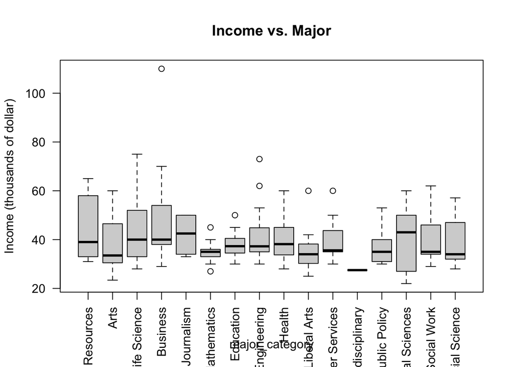

```r
boxplot(median/1000 ~ major_category, data = college, main = "Income vs. Major", ylab="Income (thousands of dollar)", las = 2)
```

We can see the distribution of the median of Income of each major is not normal, they’re skewed. However for the purpose of this project of practicing linear model, I assume they’re normal.

Analysis Let’s have a look at the major_category:

```r
unique(college$major_category)
```

```
##  [1] Engineering                         Business
##  [3] Physical Sciences                   Law & Public Policy
##  [5] Computers & Mathematics             Agriculture & Natural Resources
##  [7] Industrial Arts & Consumer Services Arts
##  [9] Health                              Social Science
## [11] Biology & Life Science              Education
## [13] Humanities & Liberal Arts           Psychology & Social Work
## [15] Communications & Journalism         Interdisciplinary
## 16 Levels: Agriculture & Natural Resources Arts ... Social Science
```

When we apply a linear model to this data, linking Income to all Majors, the default output intercept is the mean of the referenced major (alphabet sorted, with Agriculture first), the gradient coefficient of other majors is the difference of the mean of that major to the referenced one, and the p-value of those coefficients is the probability of a t-test if that mean and the referenced mean is different. For example, say we want to compare major Arts with others:

```r
major_category_ref <- relevel(college$major_category, "Arts")
fit <- lm(median ~ major_category_ref, data = college)
summary(fit)$coef
```

```
##                                                         Estimate Std. Error
## (Intercept)                                            38050.000   4036.928
## major_category_refAgriculture & Natural Resources       5450.000   5416.107
## major_category_refBiology & Life Science                5814.286   5060.557
## major_category_refBusiness                             11103.846   5130.846
## major_category_refCommunications & Journalism           3950.000   6992.164
## major_category_refComputers & Mathematics              -3110.000   5416.107
## major_category_refEducation                             -112.500   4944.206
## major_category_refEngineering                           2535.714   4577.446
## major_category_refHealth                                2266.667   5211.651
## major_category_refHumanities & Liberal Arts            -2883.333   4998.840
## major_category_refIndustrial Arts & Consumer Services   2378.571   5909.457
## major_category_refInterdisciplinary                   -10550.000  12110.783
## major_category_refLaw & Public Policy                   -250.000   6509.350
## major_category_refPhysical Sciences                     2350.000   5416.107
## major_category_refPsychology & Social Work              1838.889   5548.226
## major_category_refSocial Science                        1016.667   5548.226
##                                                           t value     Pr(>|t|)
## (Intercept)                                            9.42548470 5.898308e-17
## major_category_refAgriculture & Natural Resources      1.00625785 3.158598e-01
## major_category_refBiology & Life Science               1.14894193 2.523498e-01
## major_category_refBusiness                             2.16413574 3.198509e-02
## major_category_refCommunications & Journalism          0.56491811 5.729462e-01
## major_category_refComputers & Mathematics             -0.57421320 5.666559e-01
## major_category_refEducation                           -0.02275390 9.818758e-01
## major_category_refEngineering                          0.55395835 5.804056e-01
## major_category_refHealth                               0.43492294 6.642233e-01
## major_category_refHumanities & Liberal Arts           -0.57680046 5.649110e-01
## major_category_refIndustrial Arts & Consumer Services  0.40250254 6.878688e-01
## major_category_refInterdisciplinary                   -0.87112452 3.850334e-01
## major_category_refLaw & Public Policy                 -0.03840629 9.694132e-01
## major_category_refPhysical Sciences                    0.43389100 6.649709e-01
## major_category_refPsychology & Social Work             0.33143725 7.407619e-01
## major_category_refSocial Science                       0.18324174 8.548478e-01
```

From this result we can get some information: - mean of median of Income from major Arts is 38,050 - difference of mean of median of Income of Agriculture & Natural Resources from Arts is 5,450, and p-value of this difference is 0.31, which implies that the difference is not significant - the same interpretation can be done for coefficients of other variables

For this project, we ideally run linear regression models of income (median) vs. college major (major_catecory) for all majors as referenced. Given a referenced level, the model coefficients will indicate the difference of the mean of other variables and the probability if they are the same. I will run regression model for each major as the reference. The similar probabilities are stored in a 2D matrix A

```r
A <- matrix(, nrow = 16, ncol = 16)

for (i in 1:16){
    major_category_ref <- relevel(college$major_category, as.character(unique(college$major_category)[i]))
    fit <- lm(median ~ major_category_ref, data = college)
    tmp <- summary(fit)$coef[,4]
    # swap the first element to the corresponding position in the diagonal matrix
    tmp1 <- tmp[1:i]
    tmp1 <- c(0,tmp1)
    tmp1 <- c(tmp1[-2],tmp1[2])
    tmp1 <- tmp1[-1]
    # save to A
    A[,i] <- c(tmp1,tmp[-(1:i)])
}
```

Edit the matrix and plot.

```r
B <- data.frame(A)
names(B) <- unique(college$major_category)
B$major <- unique(college$major_category)
Bmelt <- melt(B)
```

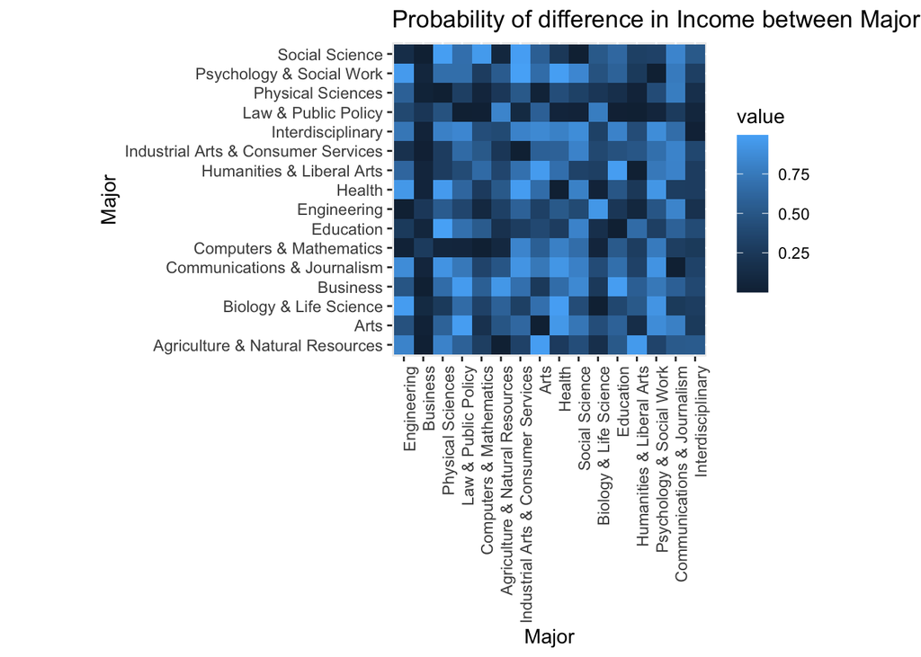

```r
g = ggplot(data=Bmelt, aes(x=variable, y=major, fill=value))
g = g + geom_tile()
g = g + theme(axis.text.x = element_text(angle = 90, hjust = 1)) + ylab("Major") + xlab("Major")
g = g + ggtitle("Probability of difference in Income between Majors")
g = g + coord_fixed()
g
```

Assuming a confidence interval of 95%, I mark all probabilities smaller than 2.5% as Different and larger than or equal to 2.5% as Same.

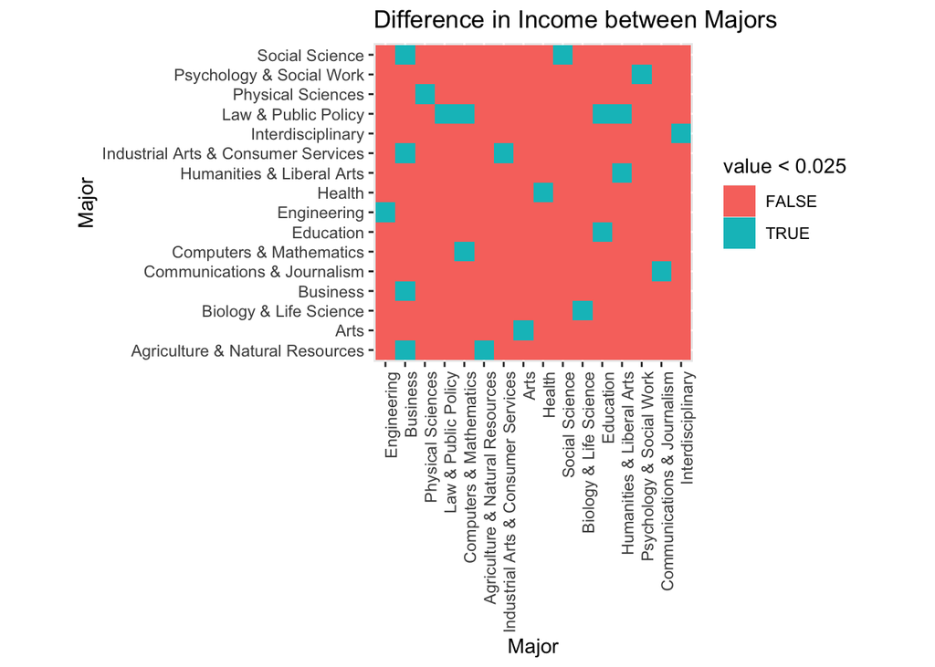

```r
g = ggplot(data=Bmelt, aes(x=variable, y=major, fill=value < 0.025))
g = g + geom_tile()
g = g + theme(axis.text.x = element_text(angle = 90, hjust = 1)) + ylab("Major") + xlab("Major")
g = g + ggtitle("Difference in Income between Majors")
g = g + coord_fixed()
g
```

```r
major_category_ref <- relevel(college$major_category, "Business")
fit <- lm(median ~ major_category_ref, data = college)
summary(fit)$coef
```

```
##                                                         Estimate Std. Error
## (Intercept)                                            49153.846   3166.827
## major_category_refAgriculture & Natural Resources      -5653.846   4802.730
## major_category_refArts                                -11103.846   5130.846
## major_category_refBiology & Life Science               -5289.560   4397.868
## major_category_refCommunications & Journalism          -7153.846   6528.580
## major_category_refComputers & Mathematics             -14213.846   4802.730
## major_category_refEducation                           -11216.346   4263.471
## major_category_refEngineering                          -8568.132   3832.103
## major_category_refHealth                               -8837.179   4570.920
## major_category_refHumanities & Liberal Arts           -13987.179   4326.709
## major_category_refIndustrial Arts & Consumer Services  -8725.275   5352.914
## major_category_refInterdisciplinary                   -21653.846  11849.180
## major_category_refLaw & Public Policy                 -11353.846   6008.631
## major_category_refPhysical Sciences                    -8753.846   4802.730
## major_category_refPsychology & Social Work             -9264.957   4951.244
## major_category_refSocial Science                      -10087.179   4951.244
##                                                         t value     Pr(>|t|)
## (Intercept)                                           15.521483 2.231581e-33
## major_category_refAgriculture & Natural Resources     -1.177215 2.409142e-01
## major_category_refArts                                -2.164136 3.198509e-02
## major_category_refBiology & Life Science              -1.202756 2.309049e-01
## major_category_refCommunications & Journalism         -1.095774 2.748775e-01
## major_category_refComputers & Mathematics             -2.959534 3.565156e-03
## major_category_refEducation                           -2.630802 9.378346e-03
## major_category_refEngineering                         -2.235882 2.678774e-02
## major_category_refHealth                              -1.933348 5.501586e-02
## major_category_refHumanities & Liberal Arts           -3.232753 1.498012e-03
## major_category_refIndustrial Arts & Consumer Services -1.630005 1.051310e-01
## major_category_refInterdisciplinary                   -1.827455 6.955453e-02
## major_category_refLaw & Public Policy                 -1.889590 6.068014e-02
## major_category_refPhysical Sciences                   -1.822681 7.027877e-02
## major_category_refPsychology & Social Work            -1.871238 6.319683e-02
## major_category_refSocial Science                      -2.037302 4.332088e-02
```

```r
business_diff <- summary(fit)$coef[-1,]
business_diff[order(business_diff[,4])[1:5],]
```

```
##                                               Estimate Std. Error   t value
## major_category_refHumanities & Liberal Arts -13987.179   4326.709 -3.232753
## major_category_refComputers & Mathematics   -14213.846   4802.730 -2.959534
## major_category_refEducation                 -11216.346   4263.471 -2.630802
## major_category_refEngineering                -8568.132   3832.103 -2.235882
## major_category_refArts                      -11103.846   5130.846 -2.164136
##                                                Pr(>|t|)
## major_category_refHumanities & Liberal Arts 0.001498012
## major_category_refComputers & Mathematics   0.003565156
## major_category_refEducation                 0.009378346
## major_category_refEngineering               0.026787738
## major_category_refArts                      0.031985089
```

```r
dance_save("~/Desktop/college_major_analysis.rds")
```